# Global GAM

### plotted predictions

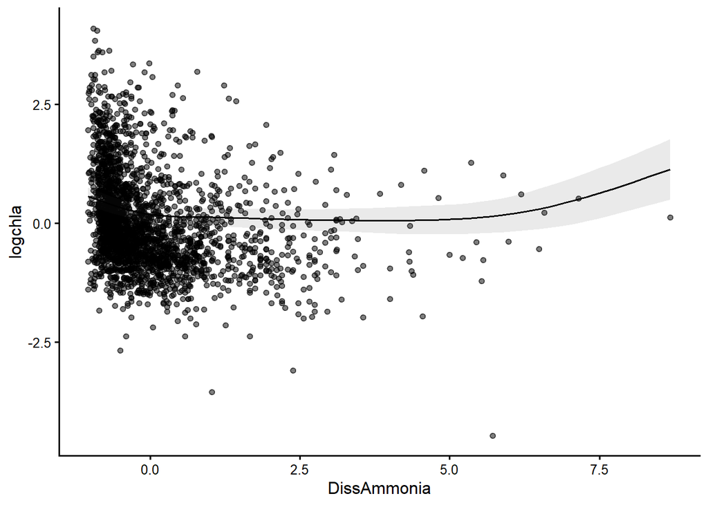

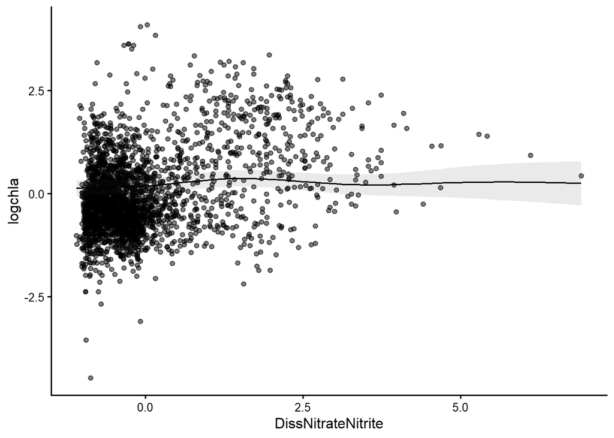

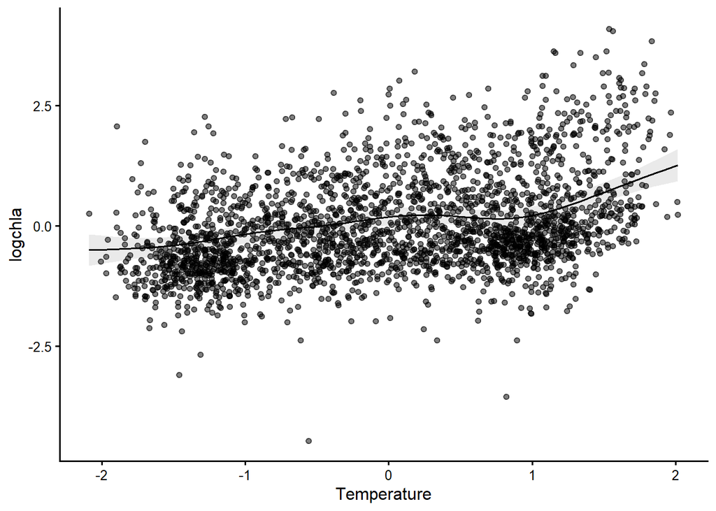

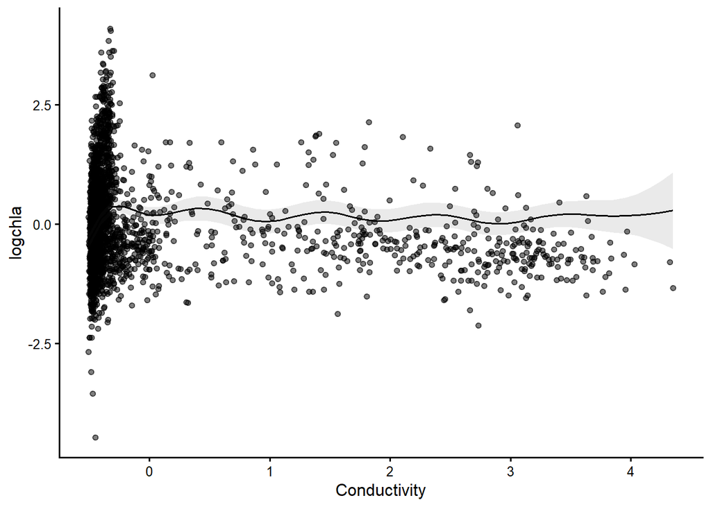

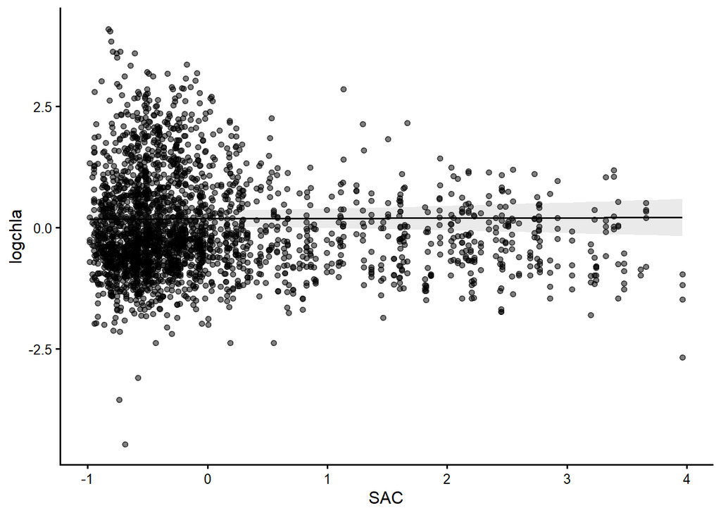

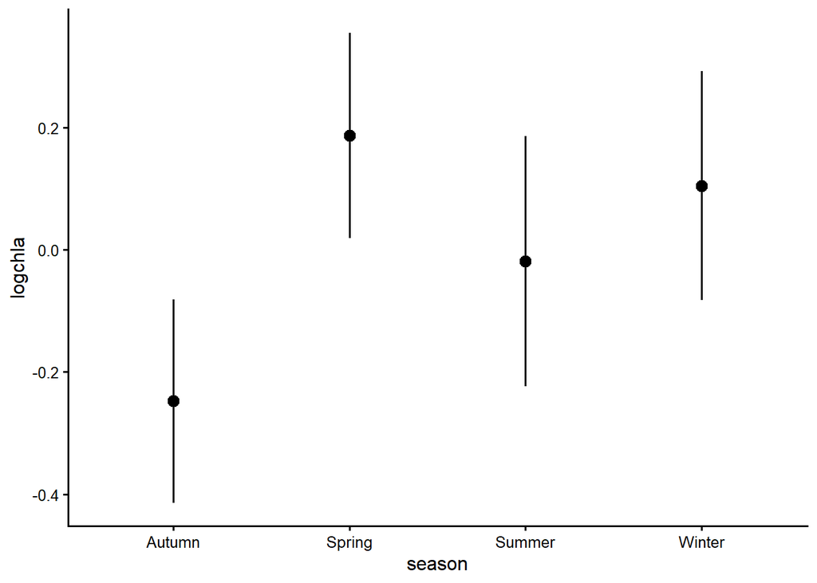

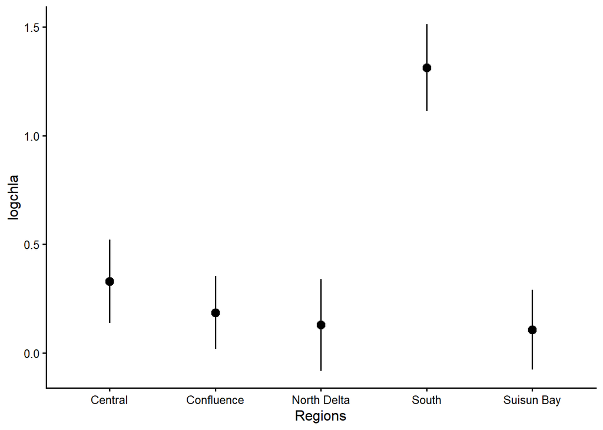

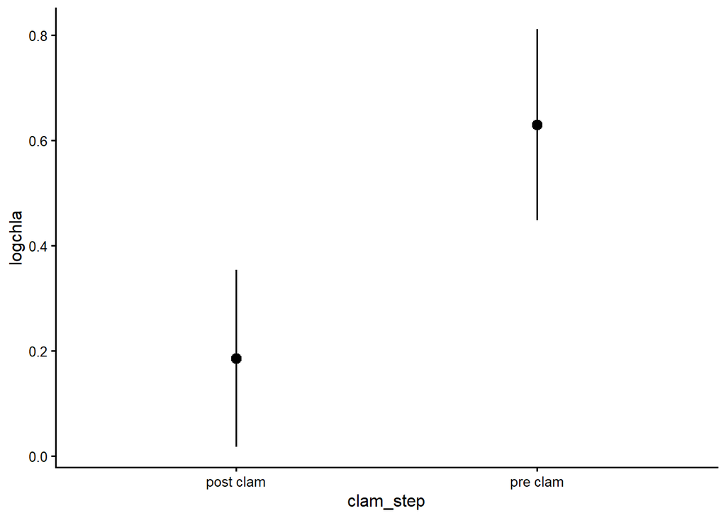

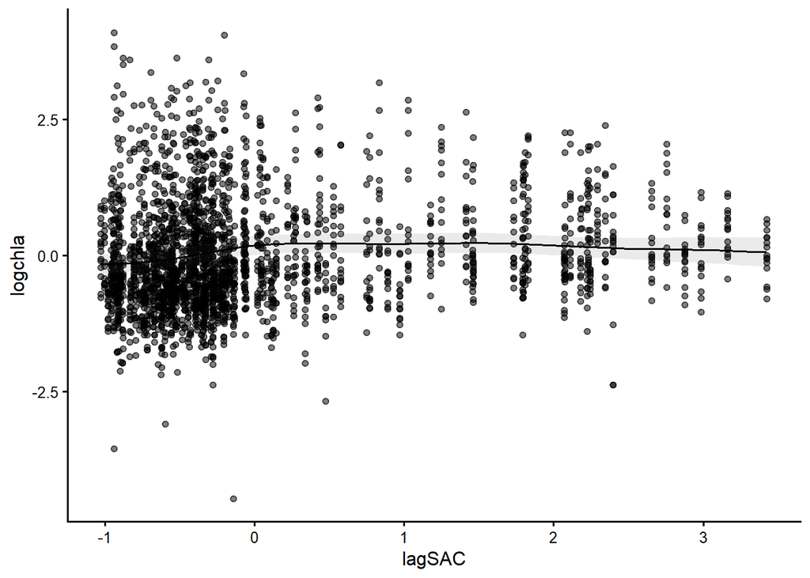

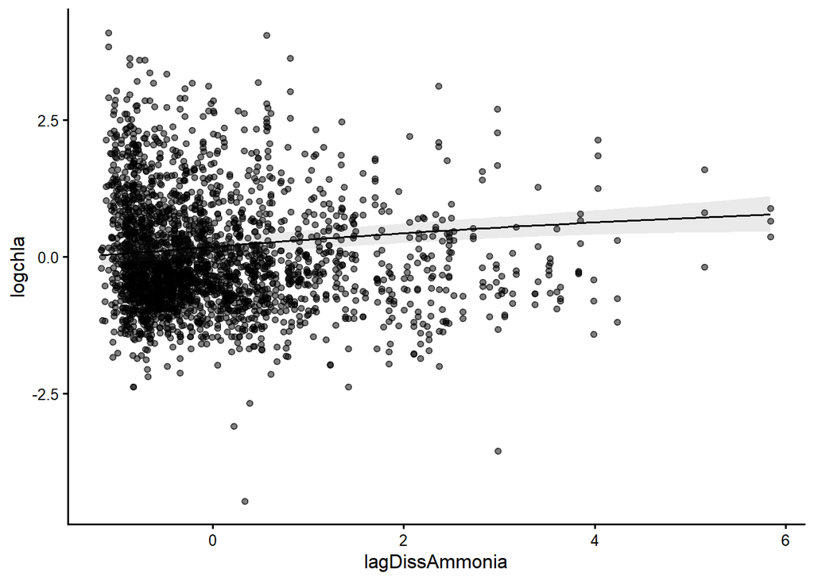

```r
c <- c("DissAmmonia",
          "DissNitrateNitrite",
          "Temperature",
          "Conductivity",
          "SAC",
          "season",
          "Regions",
          "clam_step",
          "lagSAC",
          "lagDissAmmonia")

lapply(c, function(x) {
  plot_predictions(m4.shrink, x , points = .5) +
    theme_classic(base_size = 12)
})
```

### marginal effects

The marginal effects in this plot can be interpreted as measuring the change in Y that is associated with a small increase in X, for different baseline values of X.

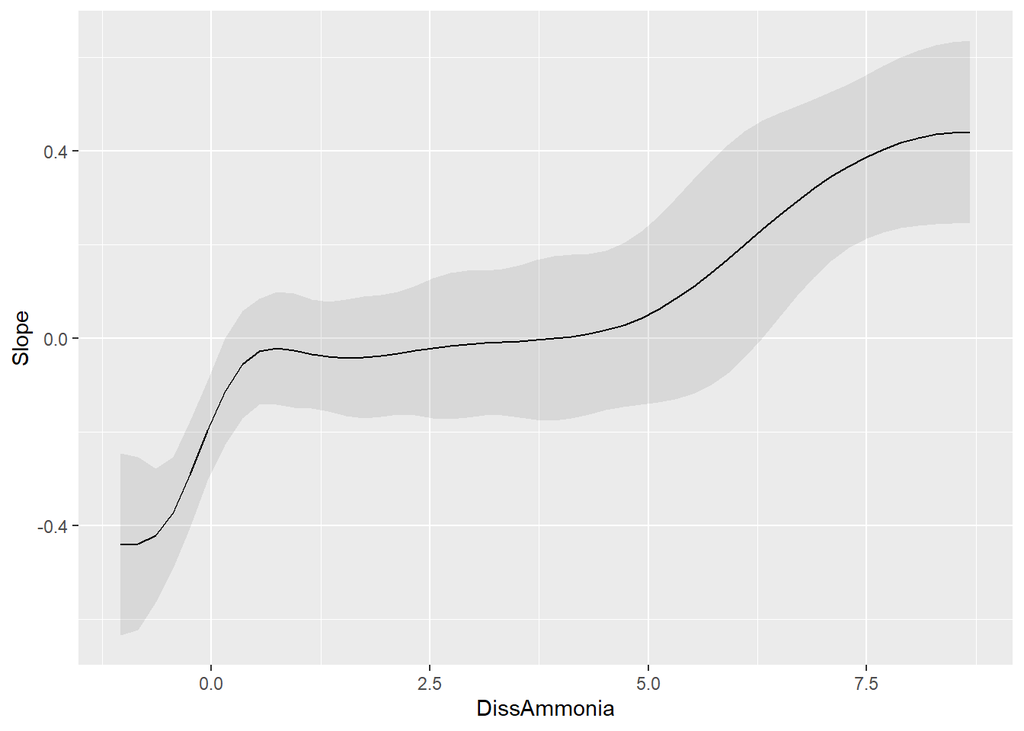

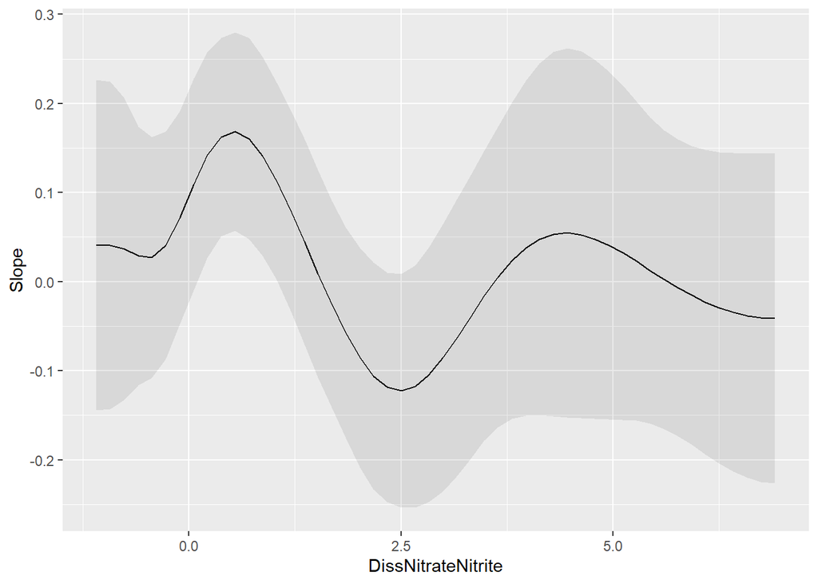

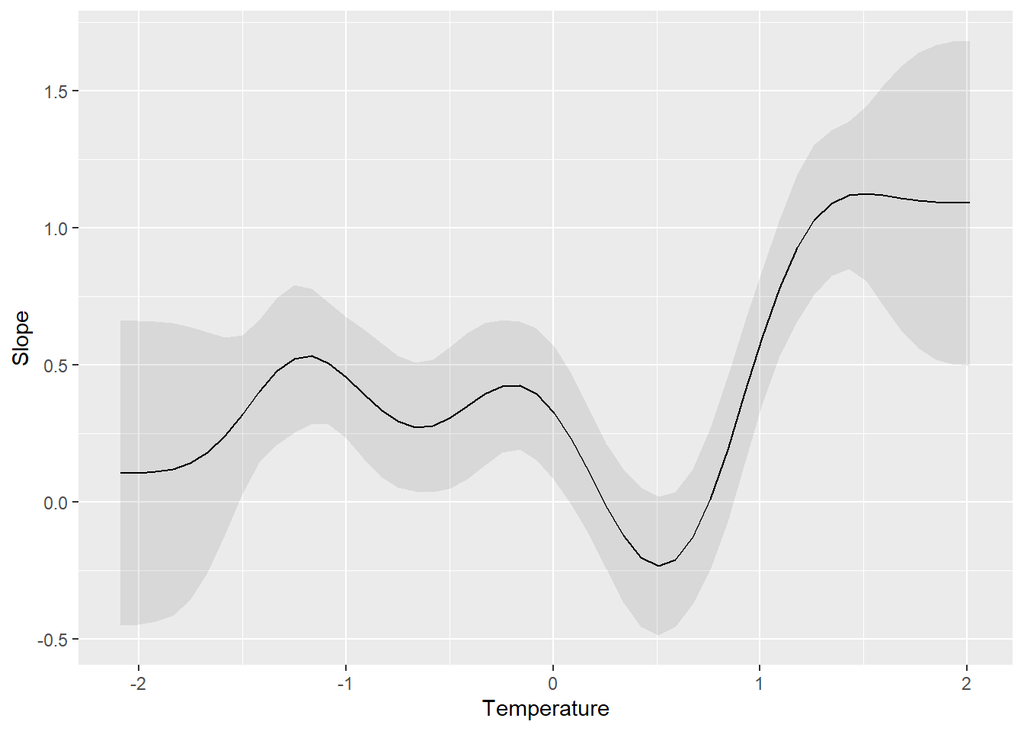

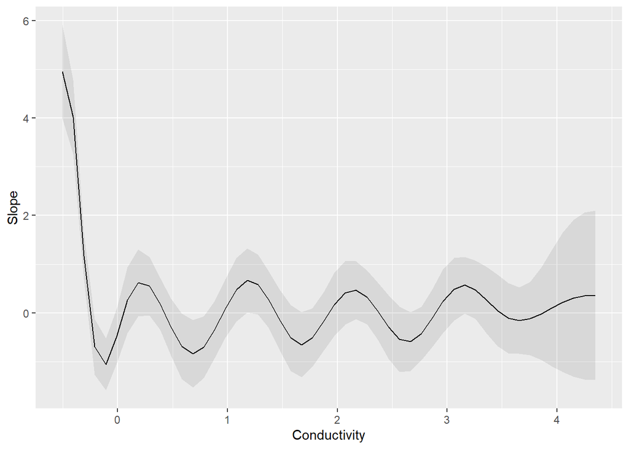

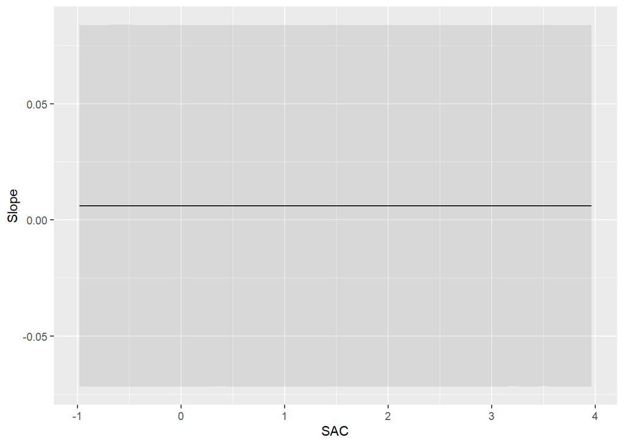

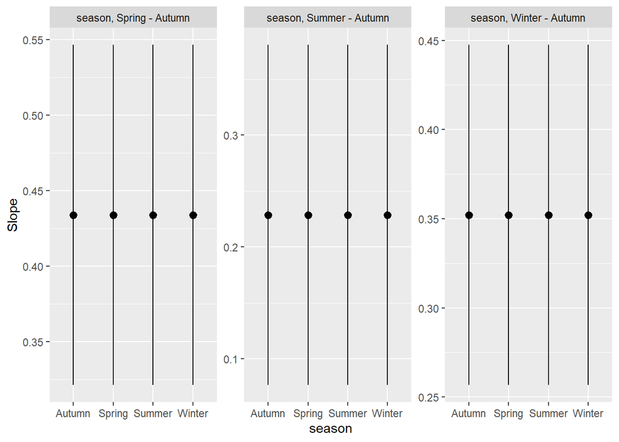

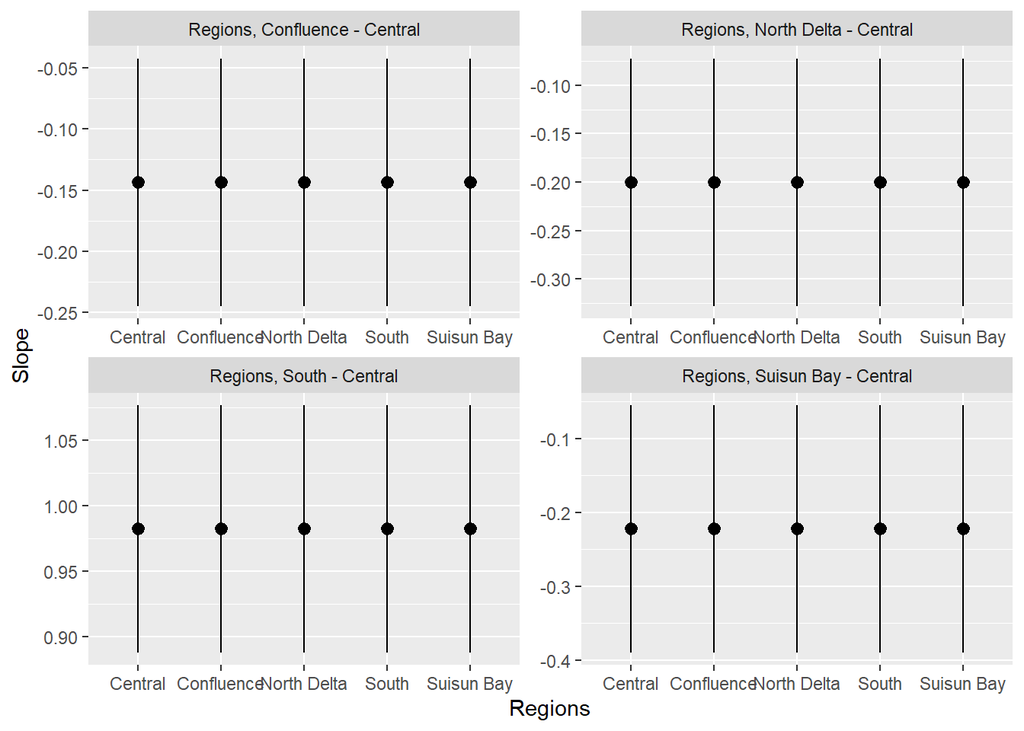

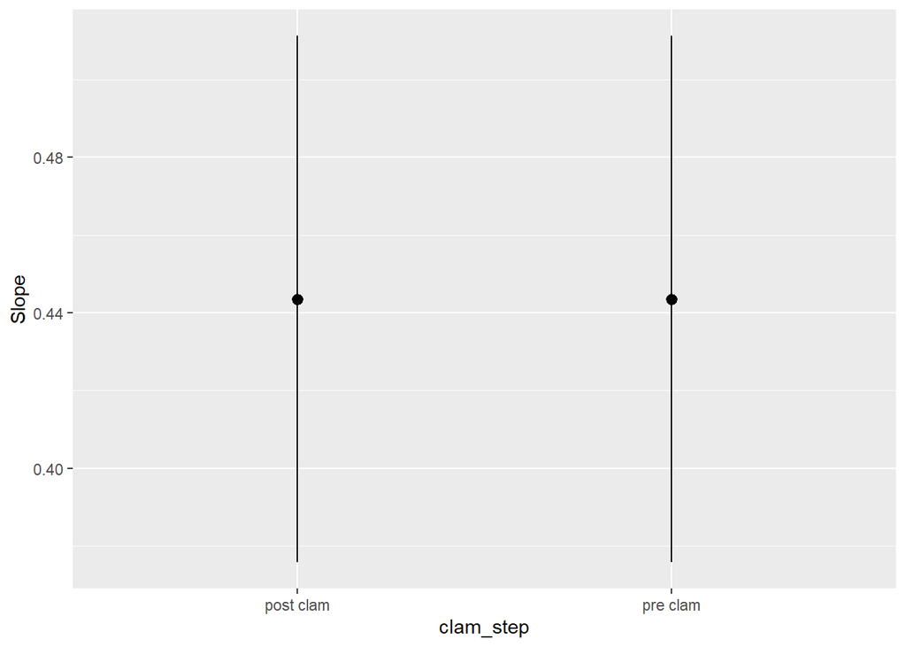

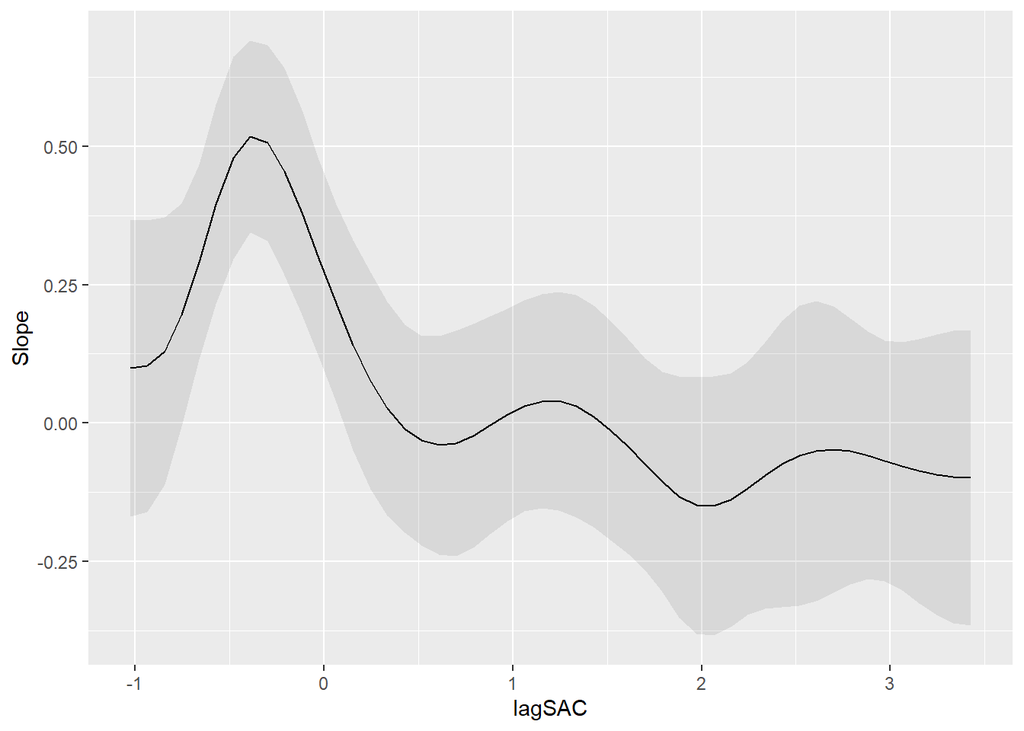

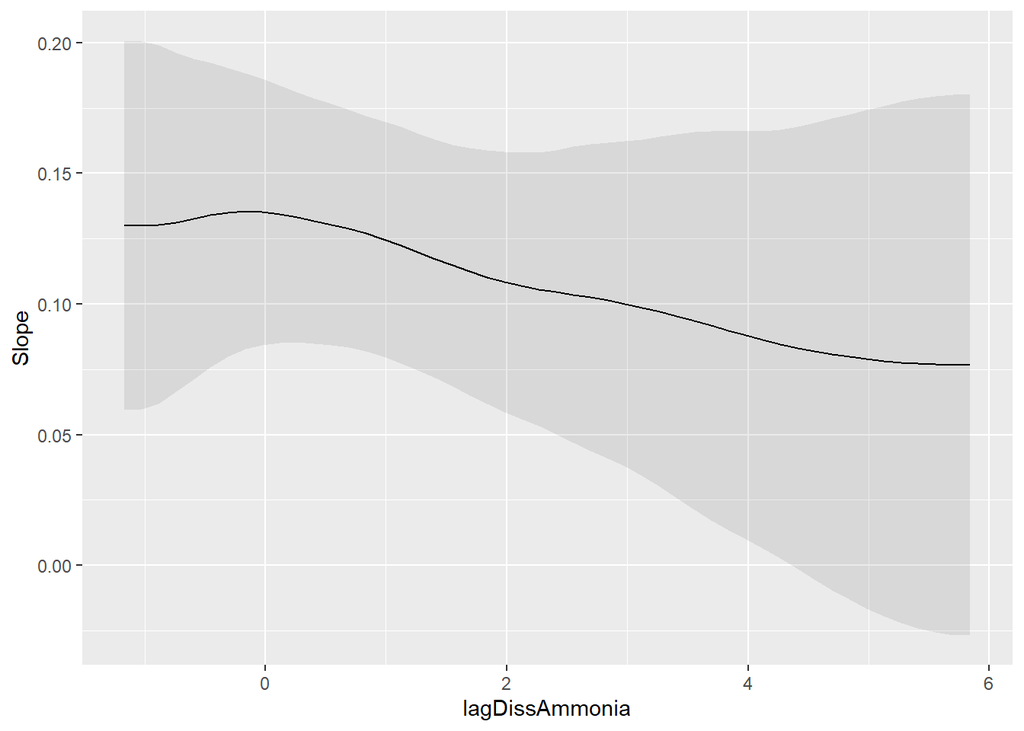

```r
c <- c("DissAmmonia",
          "DissNitrateNitrite",
          "Temperature",
          "Conductivity",
          "SAC",
          "season",
          "Regions",
          "clam_step",
          "lagSAC",
          "lagDissAmmonia")

lapply(c, function(x) {
  plot_slopes(m4.shrink, variables = x, condition = x)
})
```

### diagnostics

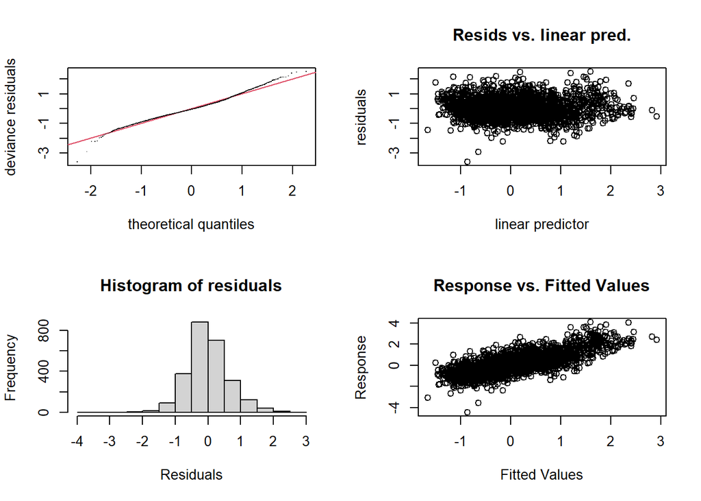

```
##
## Method: ML   Optimizer: outer newton
## full convergence after 16 iterations.
## Gradient range [-7.354257e-05,8.598656e-05]
## (score 2550.626 & scale 0.4107292).
## Hessian positive definite, eigenvalue range [4.84777e-06,1274.04].
## Model rank =  79 / 79
##
## Basis dimension (k) checking results. Low p-value (k-index<1) may
## indicate that k is too low, especially if edf is close to k'.
##
##                             k'      edf k-index p-value
## s(DissAmmonia)        9.00e+00 4.54e+00      NA      NA
## s(DissNitrateNitrite) 9.00e+00 3.63e+00      NA      NA
## s(Temperature)        9.00e+00 6.59e+00      NA      NA
## s(Conductivity)       1.10e+01 1.02e+01      NA      NA
## s(SAC)                9.00e+00 4.06e-05      NA      NA
## s(Regions)            5.00e+00 3.95e+00      NA      NA
## s(lagSAC)             9.00e+00 4.69e+00      NA      NA
## s(lagDissAmmonia)     9.00e+00 1.61e+00      NA      NA
```

```r
gam.check(m4.shrink)
```

## m6

m6: SAC + EXPORT

- gam((logchla) ~ s(DissAmmonia) + s(DissNitrateNitrite) + s(Temperature) + s(Conductivity, k=12) + s(SAC) + s(EXPORT) + s(Regions, bs=‘re’) + season + clam_step + s(lagSAC) + s(lagDissAmmonia)

### concurvity

<0.3 - low, >0.5 - some concern, >0.8 - very high

observations: EXPORT x SAC = 0.45

```r
concurvity(m6.shrink)
```

```
##          para s(DissAmmonia) s(DissNitrateNitrite) s(Temperature)
## worst       1      0.5449952             0.7881731      0.8143290
## observed    1      0.5176292             0.6134471      0.6602002
## estimate    1      0.2128518             0.3704518      0.7186020
##          s(Conductivity)    s(SAC) s(EXPORT) s(Regions) s(lagSAC)
## worst          0.8596056 0.7149259 0.6433499  1.0000000 0.6717594
## observed       0.5769288 0.4415725 0.5137881  0.6809461 0.6020677
## estimate       0.5589763 0.4772230 0.5582536  0.6630460 0.5515205
##          s(lagDissAmmonia)
## worst            0.5843938
## observed         0.5221278
## estimate         0.2926098
```

Print predictor combinations with worst-case index of concurvity >0.5

```r
w<-concurvity(m6.shrink, full =FALSE)
wdf<- as.data.frame(w$worst)
i <- which(wdf > 0.5, arr.ind = TRUE)
r <- data.frame(
  Row = rownames(wdf)[i[, 1]],
  Column = colnames(wdf)[i[, 2]],
  Value = wdf[i]
)
r <- r[r$Row != r$Column, ]
r
```

|  | Row | Column | Value |
| --- | --- | --- | --- |
| 2 | s(Regions) | para | 1.0000000 |
| 5 | s(Regions) | s(DissNitrateNitrite) | 0.5971421 |
| 8 | s(Regions) | s(Conductivity) | 0.7778515 |
| 11 | para | s(Regions) | 1.0000000 |
| 12 | s(DissNitrateNitrite) | s(Regions) | 0.5971421 |
| 13 | s(Conductivity) | s(Regions) | 0.7778515 |

### VIF

```r
m.l<- lm(formula = logchla ~ SAC+ EXPORT + clam_step,
            data=df)
vif(m.l)
```

```
##       SAC    EXPORT clam_step
##  1.035789  1.015307  1.020426
```

### plotted predicitons

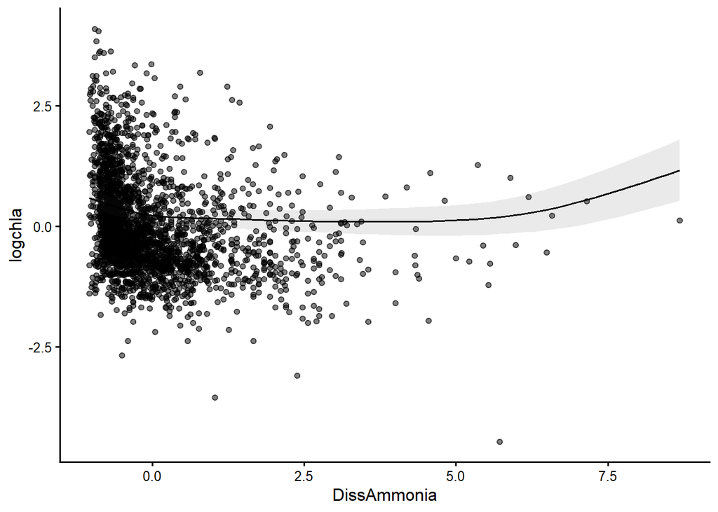

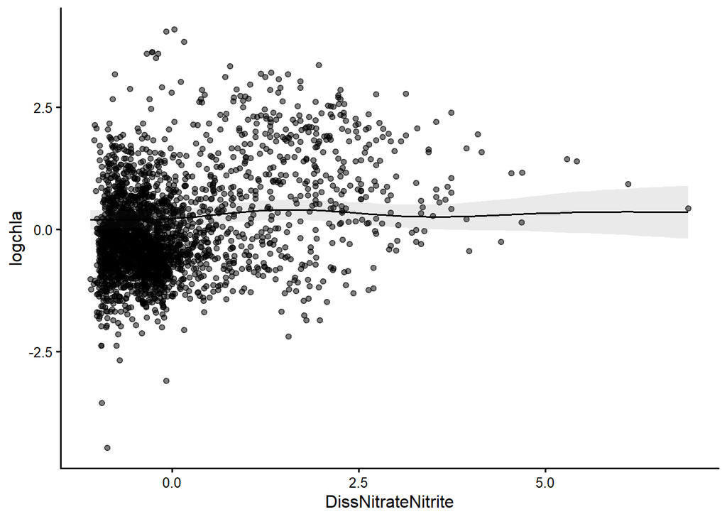

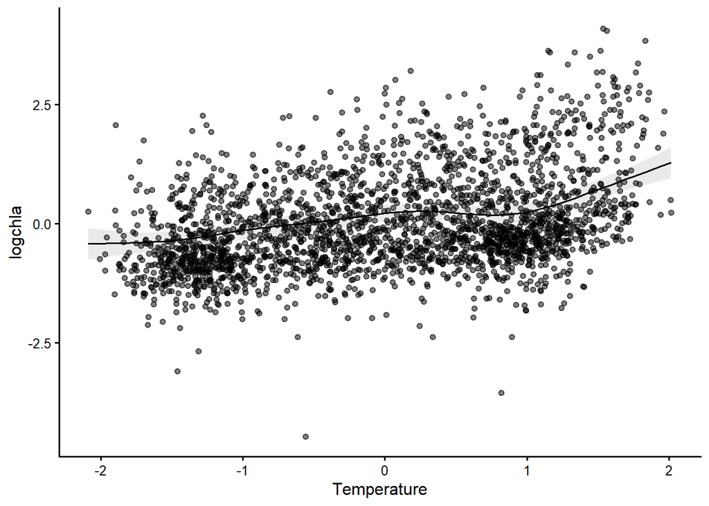

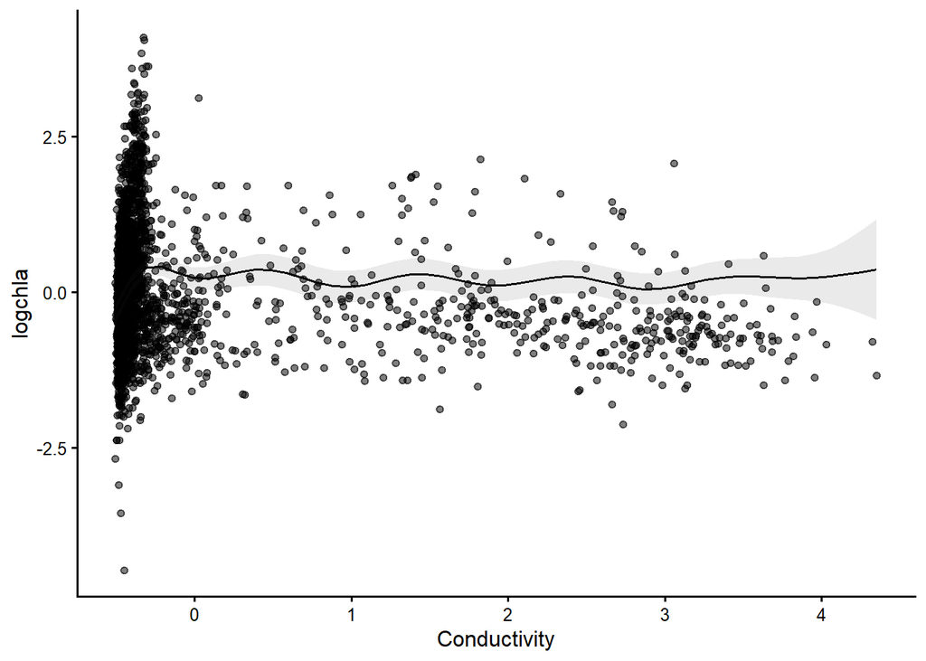

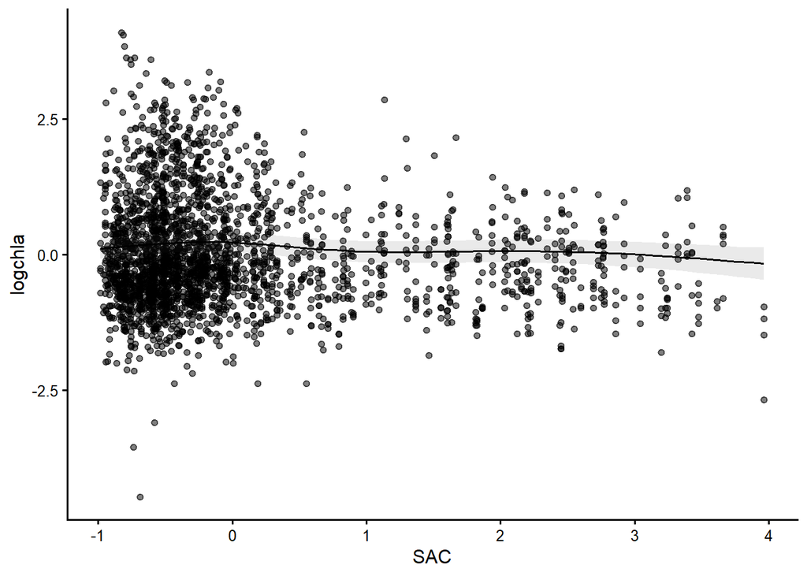

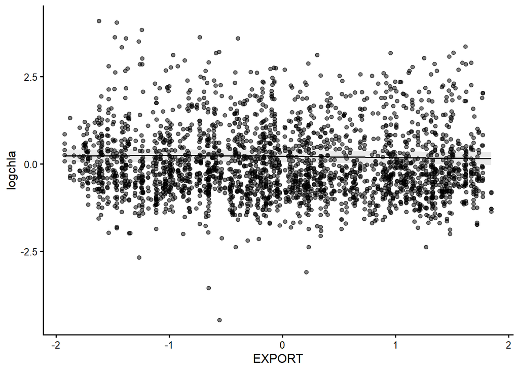

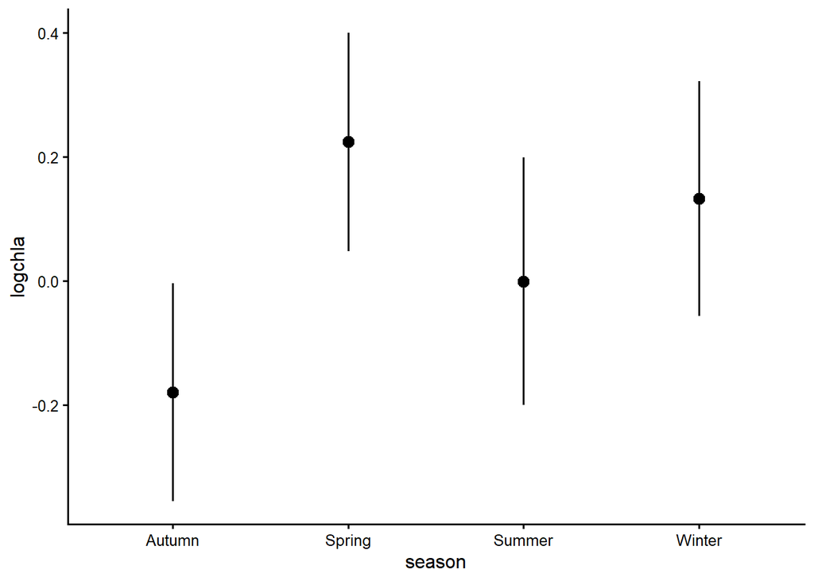

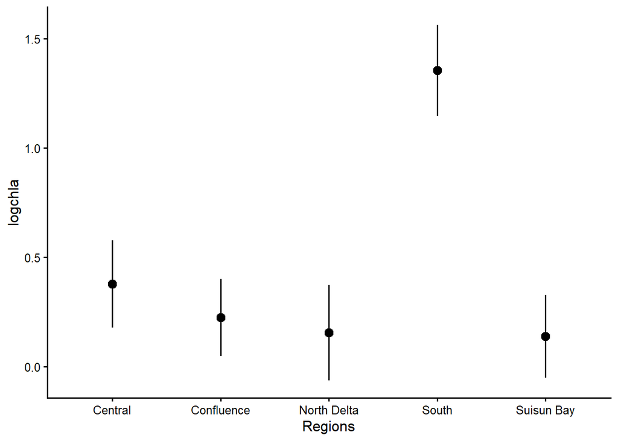

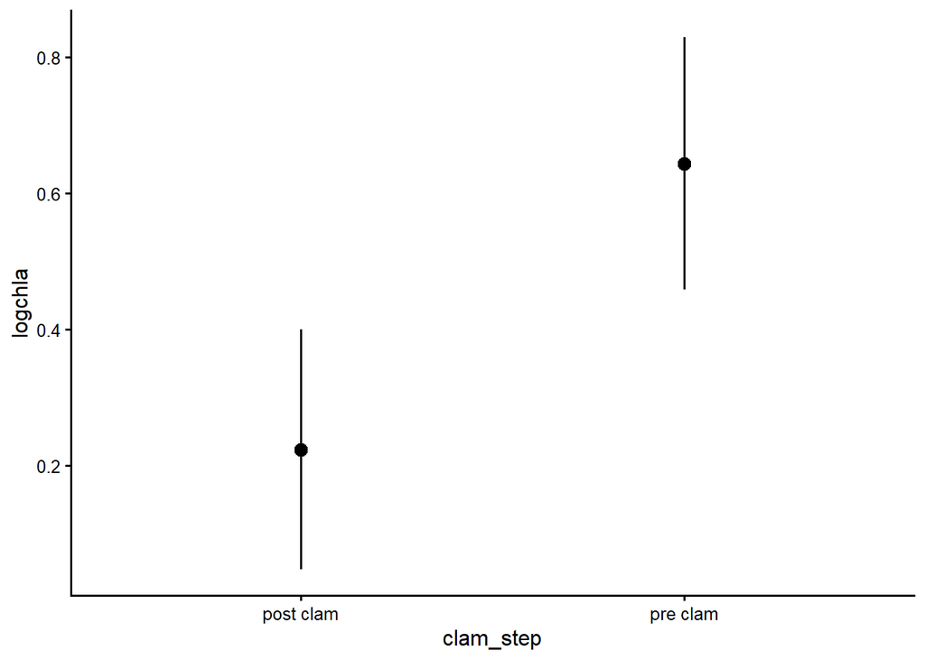

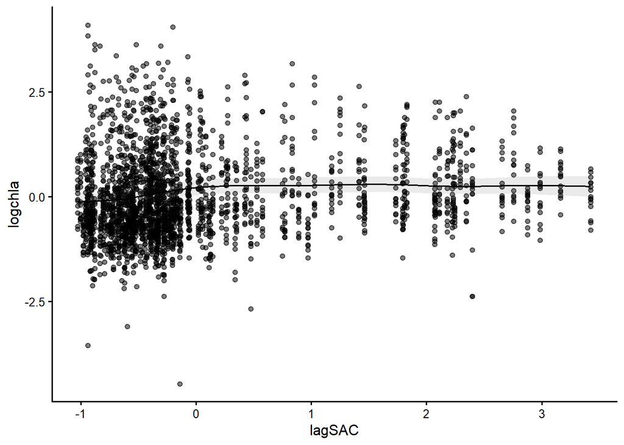

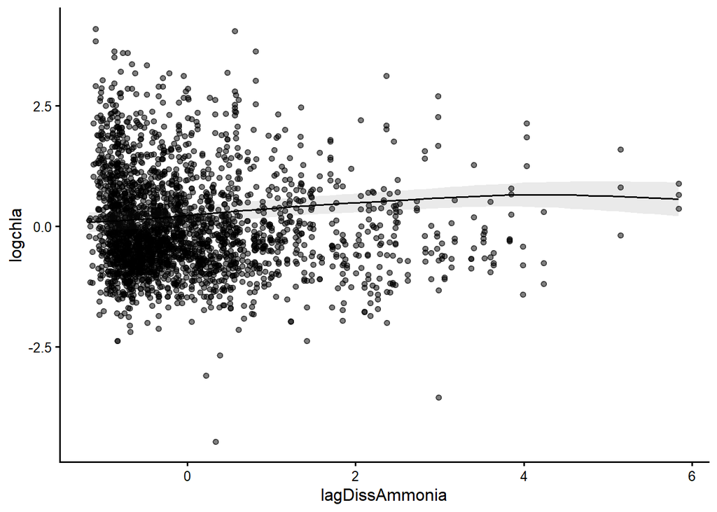

```r
# Plot data with model fit
c <- c("DissAmmonia",
          "DissNitrateNitrite",
          "Temperature",
          "Conductivity",
          "SAC",
          "EXPORT",
          "season",
          "Regions",
          "clam_step",
          "lagSAC",
          "lagDissAmmonia")

lapply(c, function(x) {
  plot_predictions(m6.shrink, condition = x , points = .5) +
    theme_classic(base_size = 12)
})
```

### marginal effects

The marginal effects in this plot can be interpreted as measuring the change in Y that is associated with a small increase in X, for different baseline values of X.

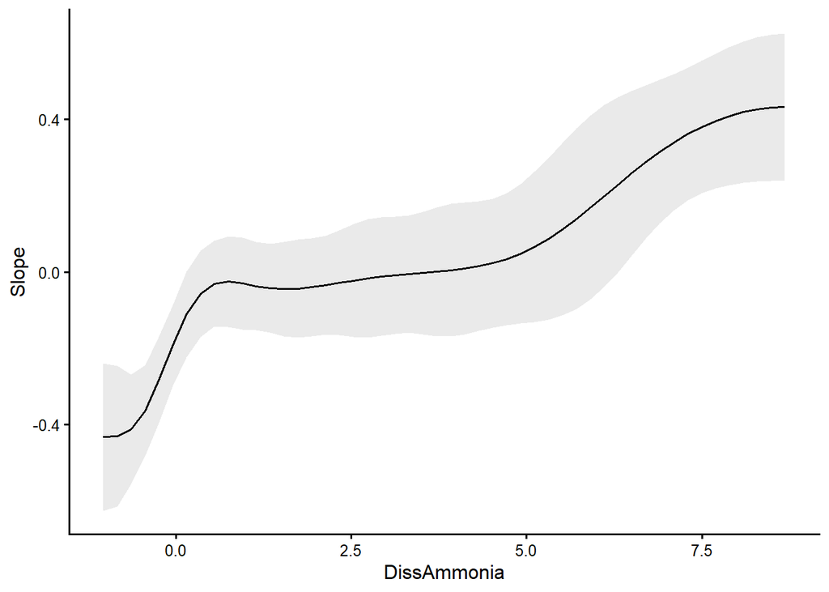

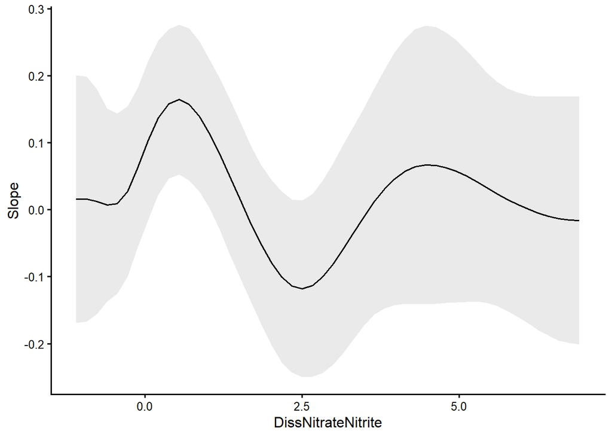

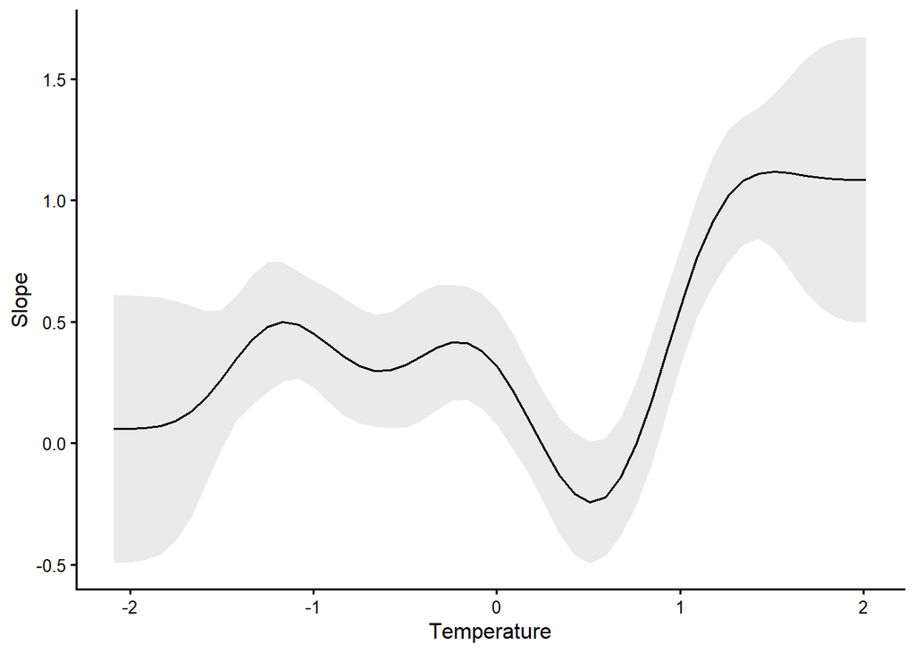

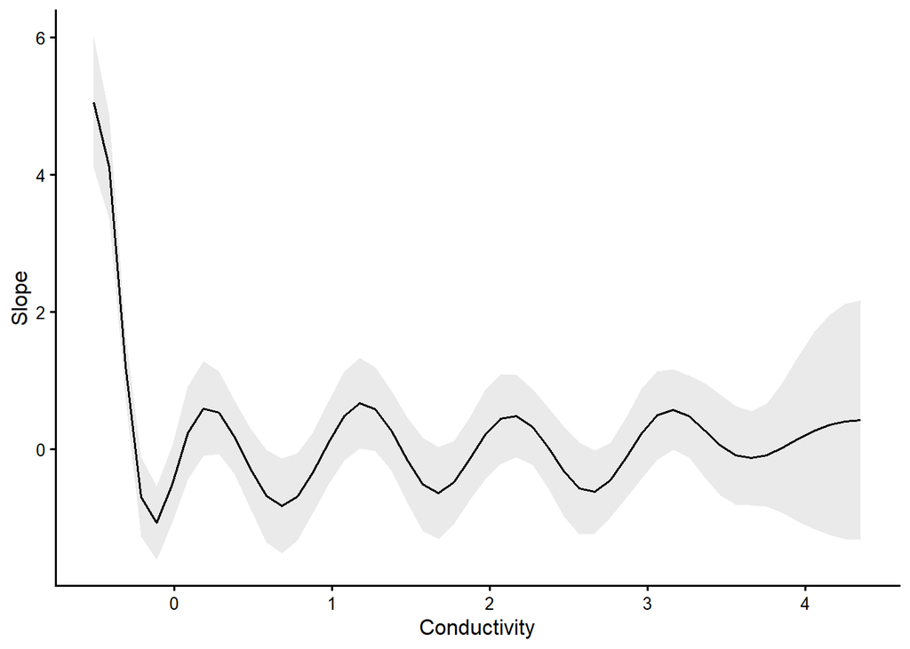

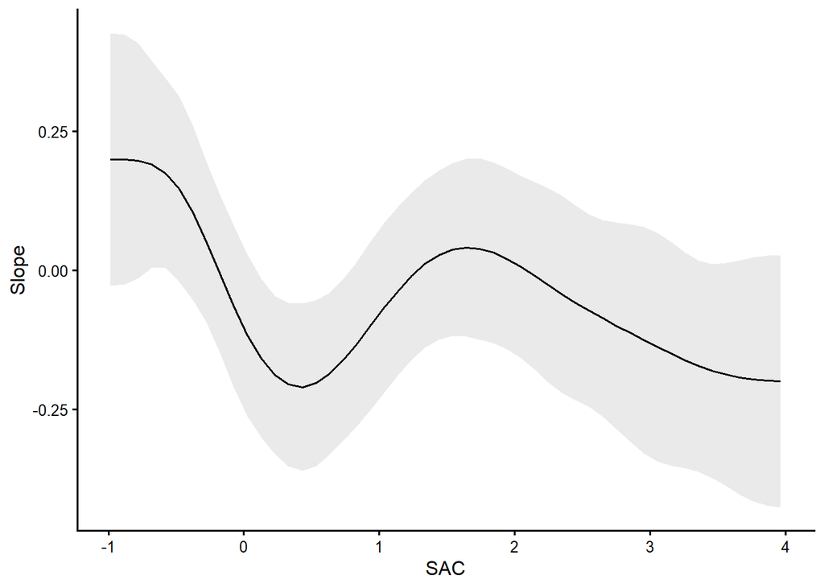

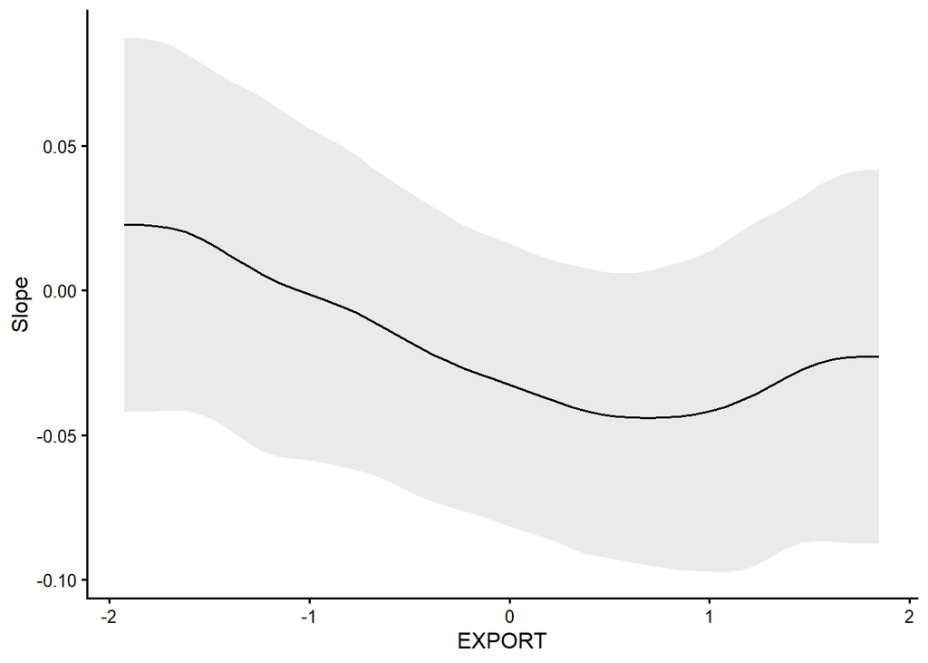

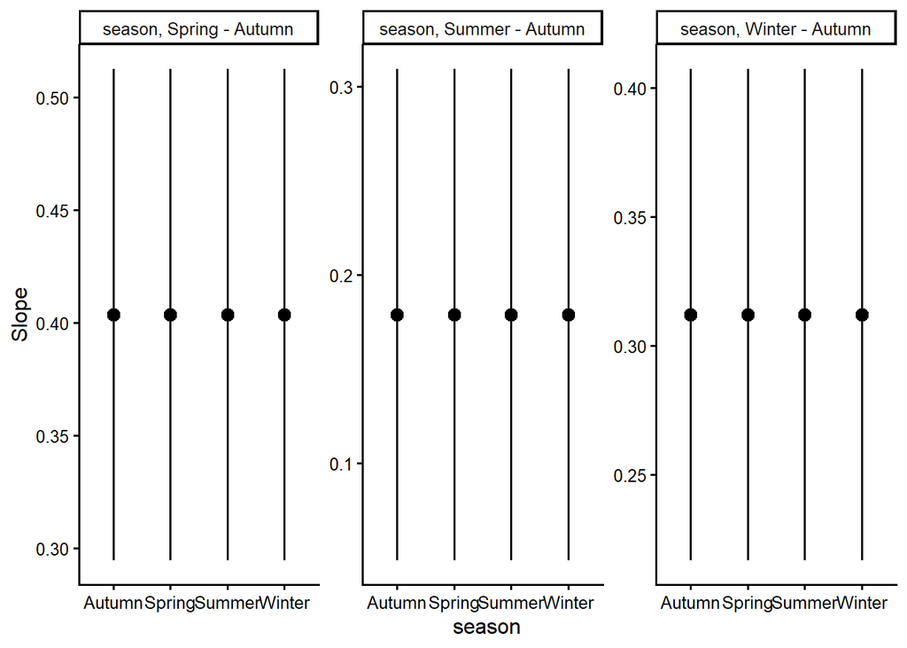

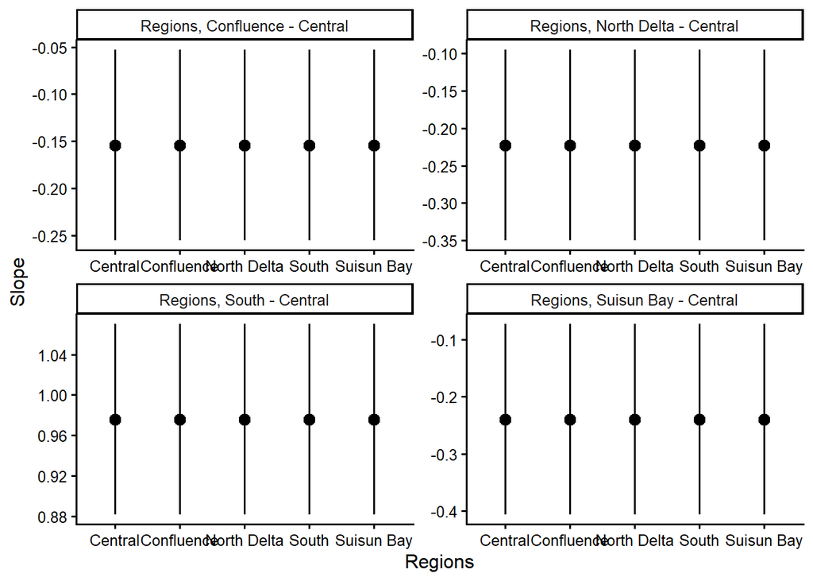

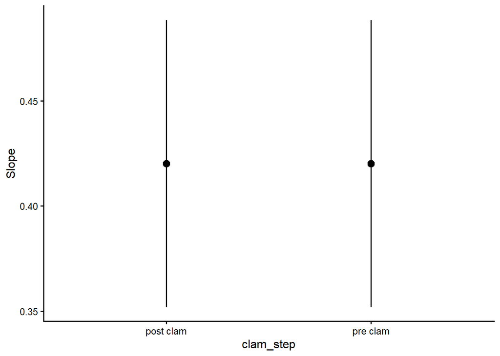

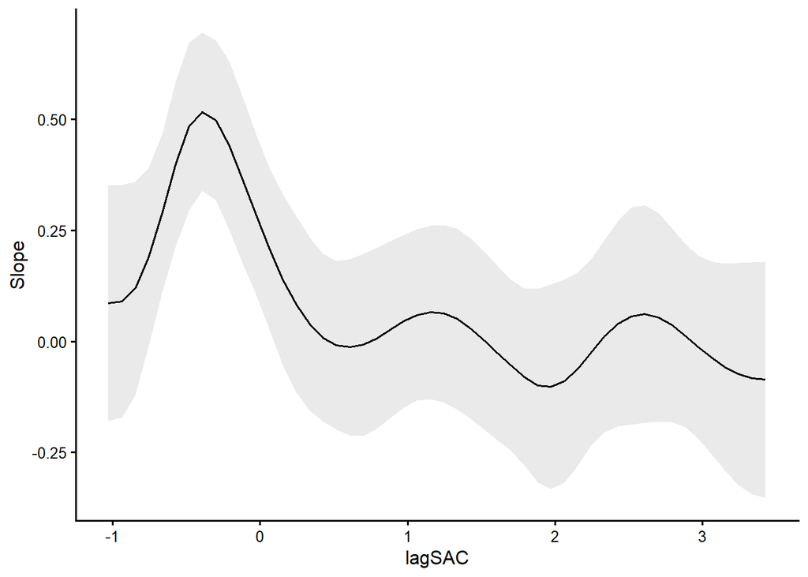

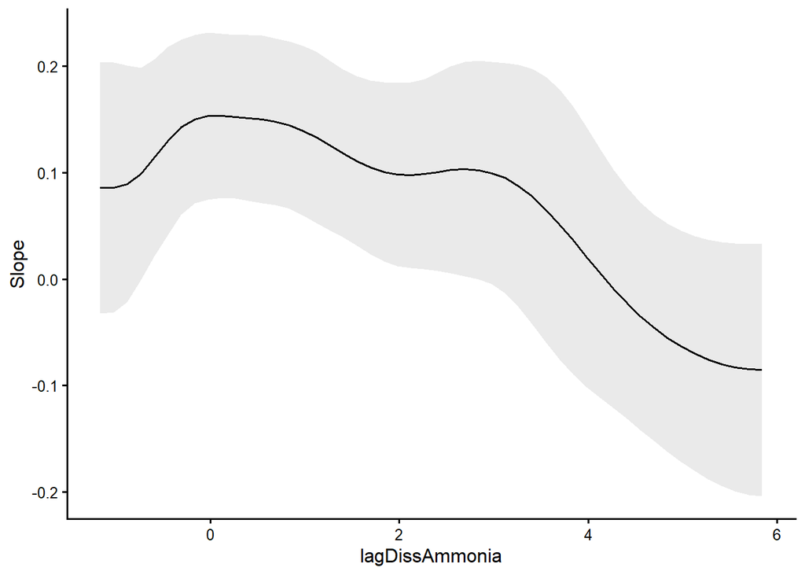

```r
c <- c("DissAmmonia",
          "DissNitrateNitrite",
          "Temperature",
          "Conductivity",
          "SAC",
          "EXPORT",
          "season",
          "Regions",
          "clam_step",
          "lagSAC",
          "lagDissAmmonia")


lapply(c, function(x) {
  plot_slopes(m6.shrink, condition = x , variables = x) +
    theme_classic(base_size = 12)
})
```

### diagnostics

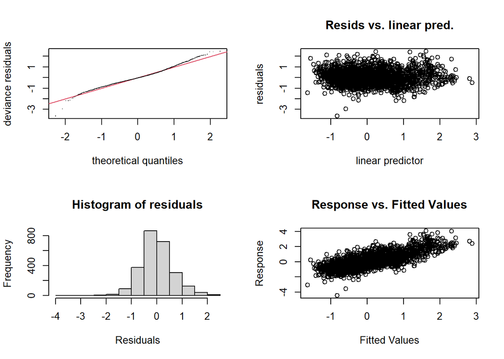

```
##
## Method: ML   Optimizer: outer newton
## full convergence after 17 iterations.
## Gradient range [-9.009342e-05,6.116581e-05]
## (score 2555.321 & scale 0.4091024).
## eigenvalue range [-6.138385e-05,1274.044].
## Model rank =  84 / 84
##
## Basis dimension (k) checking results. Low p-value (k-index<1) may
## indicate that k is too low, especially if edf is close to k'.
##
##                          k'   edf k-index p-value
## s(DissAmmonia)         9.00  4.49      NA      NA
## s(DissNitrateNitrite)  9.00  3.65      NA      NA
## s(Temperature)         9.00  6.57      NA      NA
## s(Conductivity)       11.00 10.24      NA      NA
## s(SAC)                 9.00  3.84      NA      NA
## s(EXPORT)              9.00  1.27      NA      NA
## s(Regions)             5.00  3.95      NA      NA
## s(lagSAC)              9.00  4.78      NA      NA
## s(lagDissAmmonia)      9.00  2.64      NA      NA
```

```r
gam.check(m6.shrink)
```

## m3.no.season

m3.no.season: OUT, no season or OUT:season

- gam((logchla) ~ s(DissAmmonia) + s(DissNitrateNitrite) + s(Temperature) + s(Conductivity) + s(OUT) + s(Regions, bs=‘re’) + clam_step + s(lagOUT) + s(lagDissAmmonia) + s(lagDissNitrateNitrite)

### concurvity

<0.3 - low, >0.5 - some concern, >0.8 - very high

```r
concurvity(m3.no.season.shrink)
```

```
##          para s(DissAmmonia) s(DissNitrateNitrite) s(Temperature)
## worst       1      0.5380616             0.7970190      0.6794623
## observed    1      0.5092585             0.5203502      0.5271972
## estimate    1      0.2127995             0.3869927      0.5701822
##          s(Conductivity)    s(OUT) s(Regions) s(lagOUT) s(lagDissAmmonia)
## worst          0.8600972 0.7144543  1.0000000 0.6493923         0.5885259
## observed       0.5224231 0.2012340  0.7259395 0.5925158         0.5262263
## estimate       0.5800987 0.2404314  0.7013626 0.3248433         0.3006126
##          s(lagDissNitrateNitrite)
## worst                   0.8132552
## observed                0.6601256
## estimate                0.5093843
```

Print predictor combinations with worst-case index of concurvity >0.5

```r
w<-concurvity(m3.no.season.shrink, full =FALSE)
wdf<- as.data.frame(w$worst)
i <- which(wdf > 0.5, arr.ind = TRUE)
r <- data.frame(
  Row = rownames(wdf)[i[, 1]],
  Column = colnames(wdf)[i[, 2]],
  Value = wdf[i]
)
r <- r[r$Row != r$Column, ]
r
```

|  | Row | Column | Value |
| --- | --- | --- | --- |
| 2 | s(Regions) | para | 1.0000000 |
| 5 | s(Regions) | s(DissNitrateNitrite) | 0.5971421 |
| 6 | s(lagDissNitrateNitrite) | s(DissNitrateNitrite) | 0.5346351 |
| 9 | s(Regions) | s(Conductivity) | 0.7775636 |
| 11 | para | s(Regions) | 1.0000000 |
| 12 | s(DissNitrateNitrite) | s(Regions) | 0.5971421 |
| 13 | s(Conductivity) | s(Regions) | 0.7775636 |
| 15 | s(lagDissNitrateNitrite) | s(Regions) | 0.6575696 |
| 18 | s(DissNitrateNitrite) | s(lagDissNitrateNitrite) | 0.5346351 |
| 19 | s(Regions) | s(lagDissNitrateNitrite) | 0.6575696 |

### plotted predictions

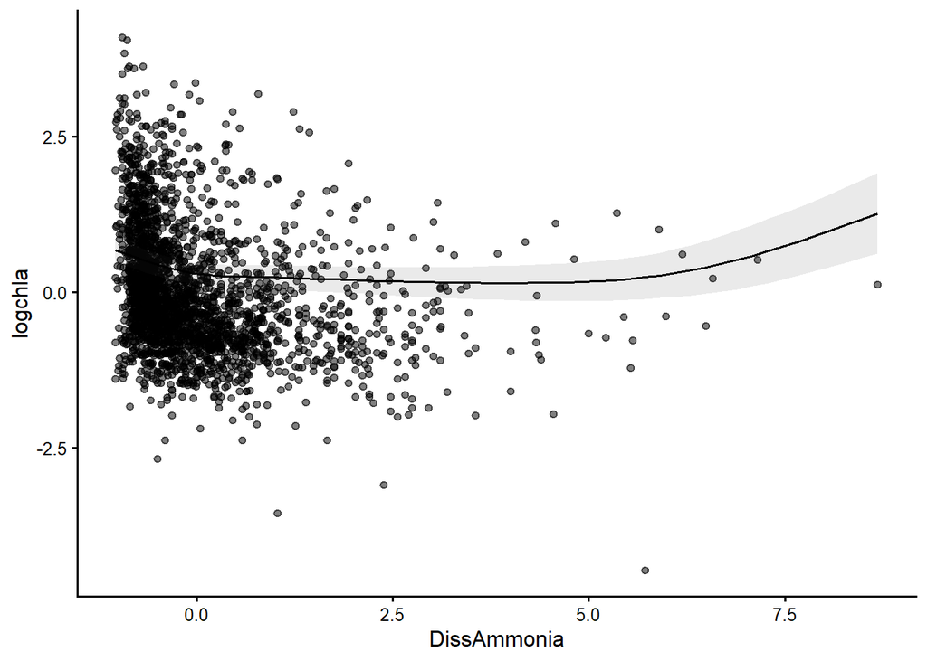

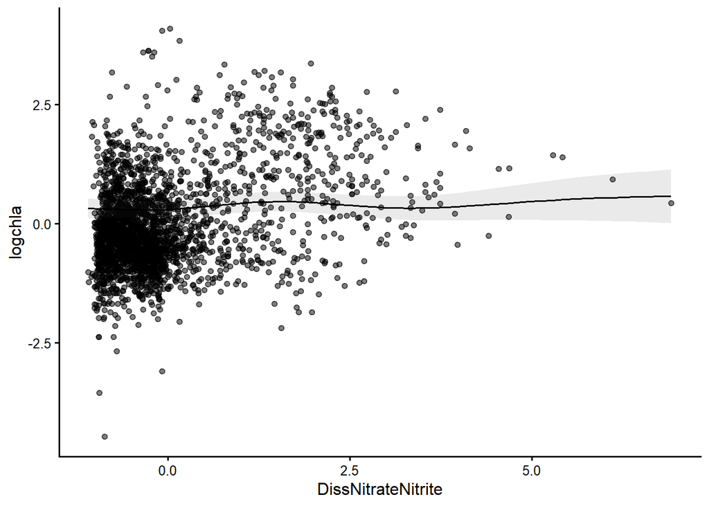

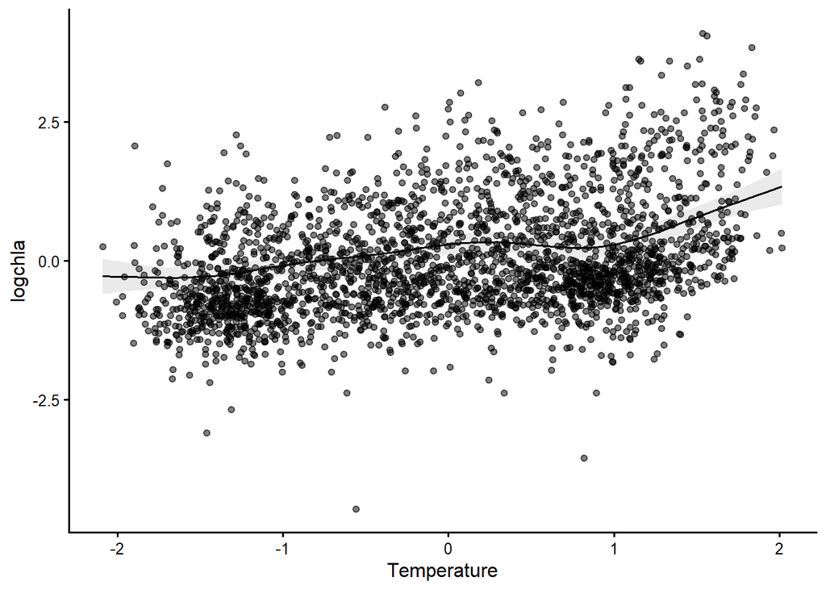

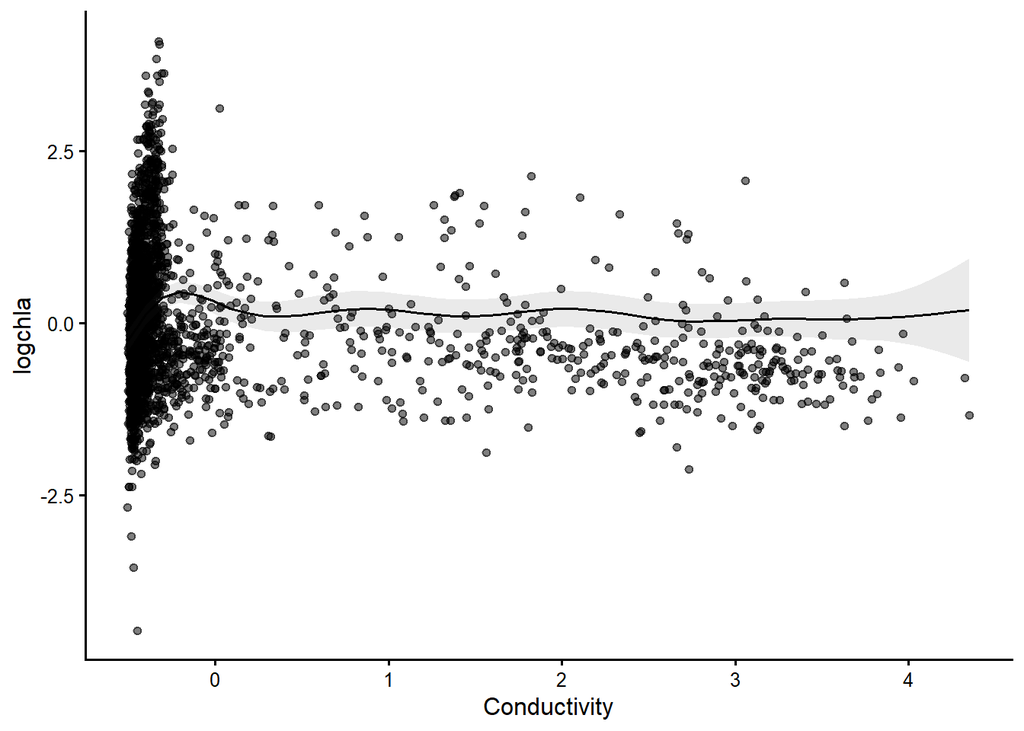

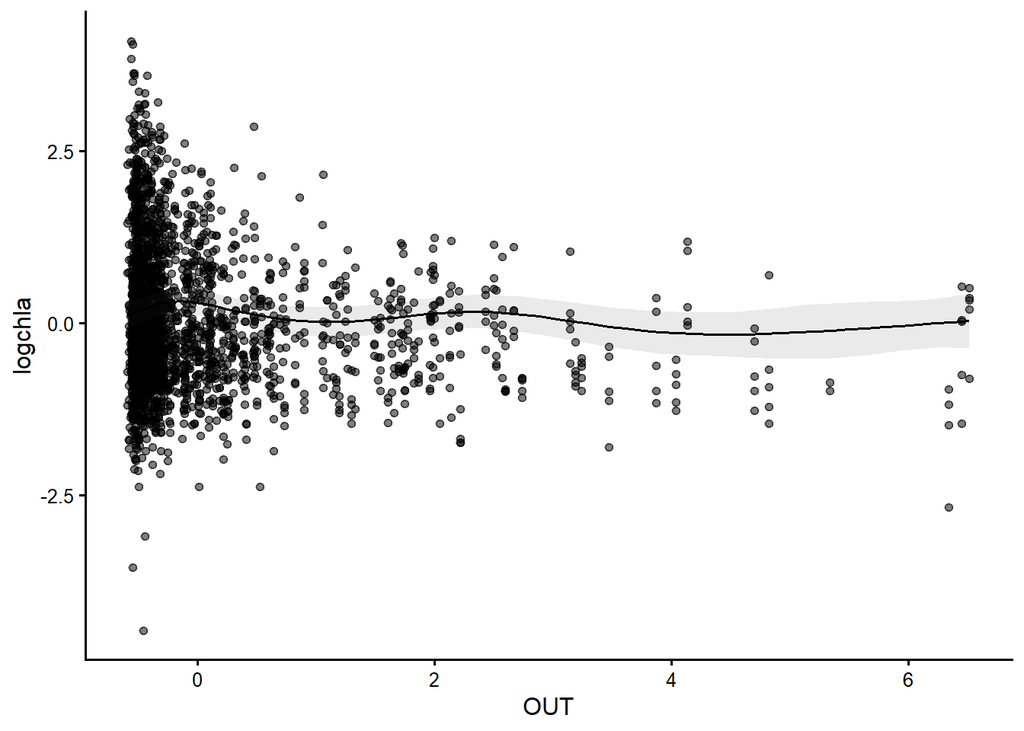

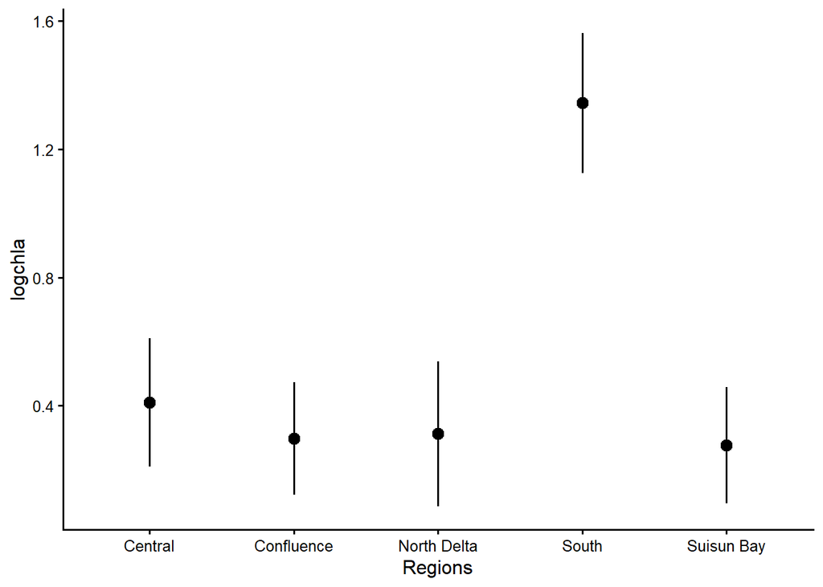

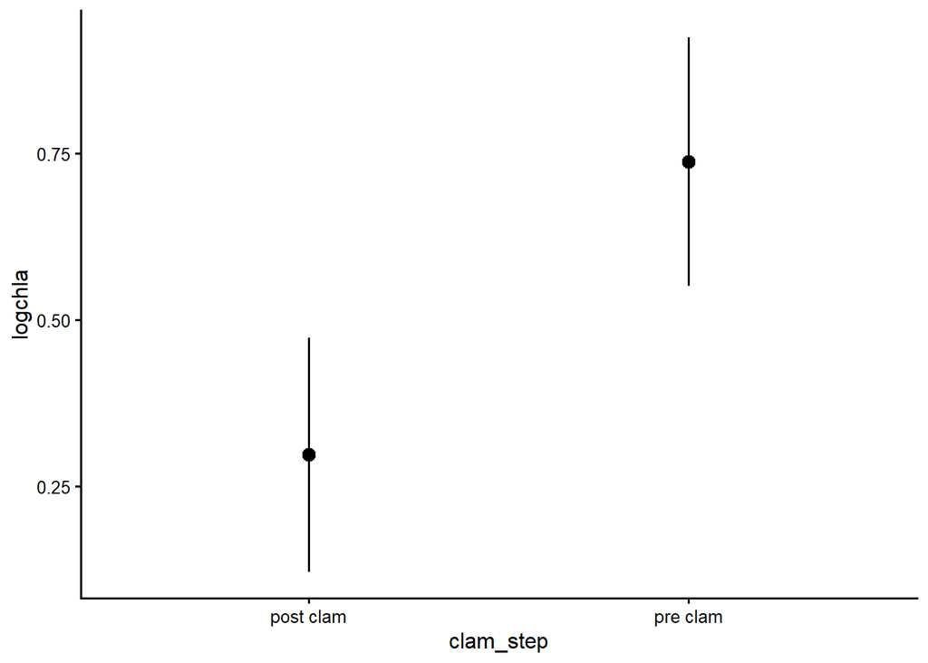

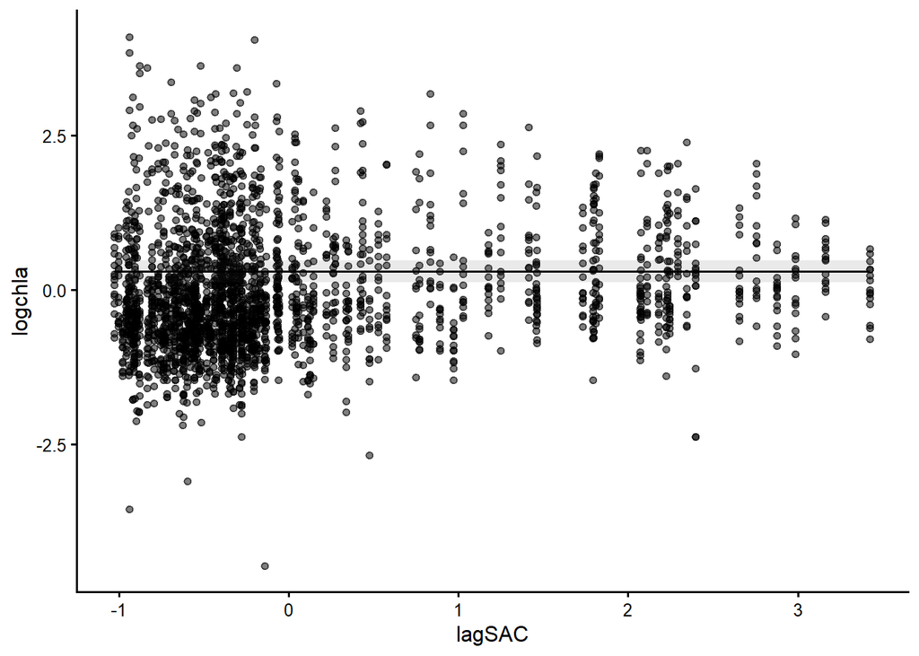

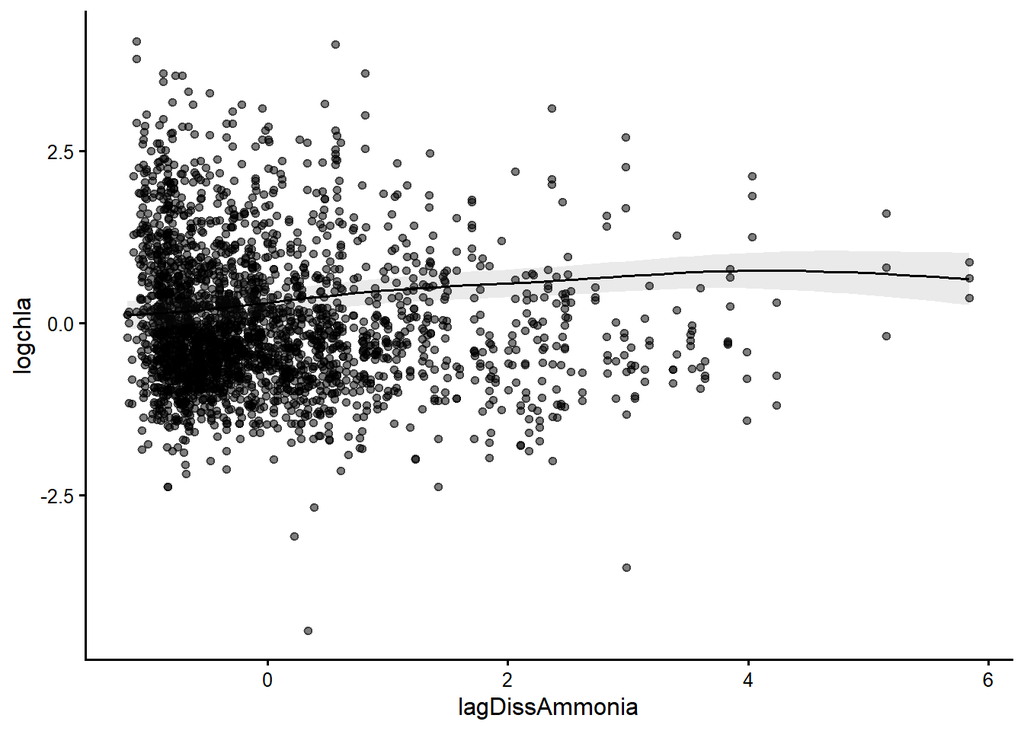

```r
c <- c("DissAmmonia",
          "DissNitrateNitrite",
          "Temperature",
          "Conductivity",
          "OUT",
          "Regions",
          "clam_step",
          "lagSAC",
          "lagDissAmmonia")

lapply(c, function(x) {
  plot_predictions(m3.no.season.shrink, x , points = .5) +
    theme_classic(base_size = 12)
})
```

### marginal effects

The marginal effects in this plot can be interpreted as measuring the change in Y that is associated with a small increase in X, for different baseline values of X.

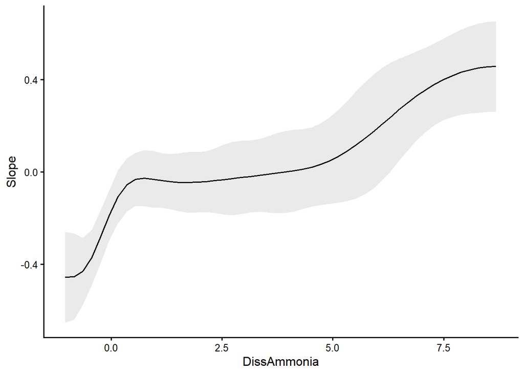

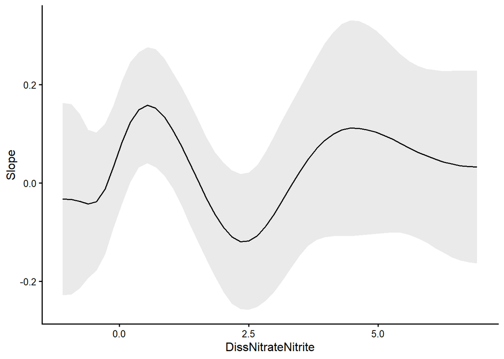

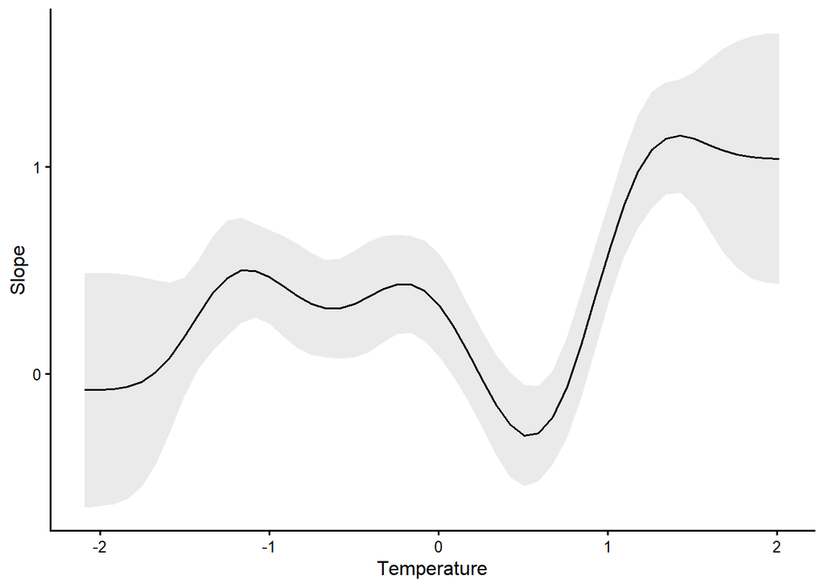

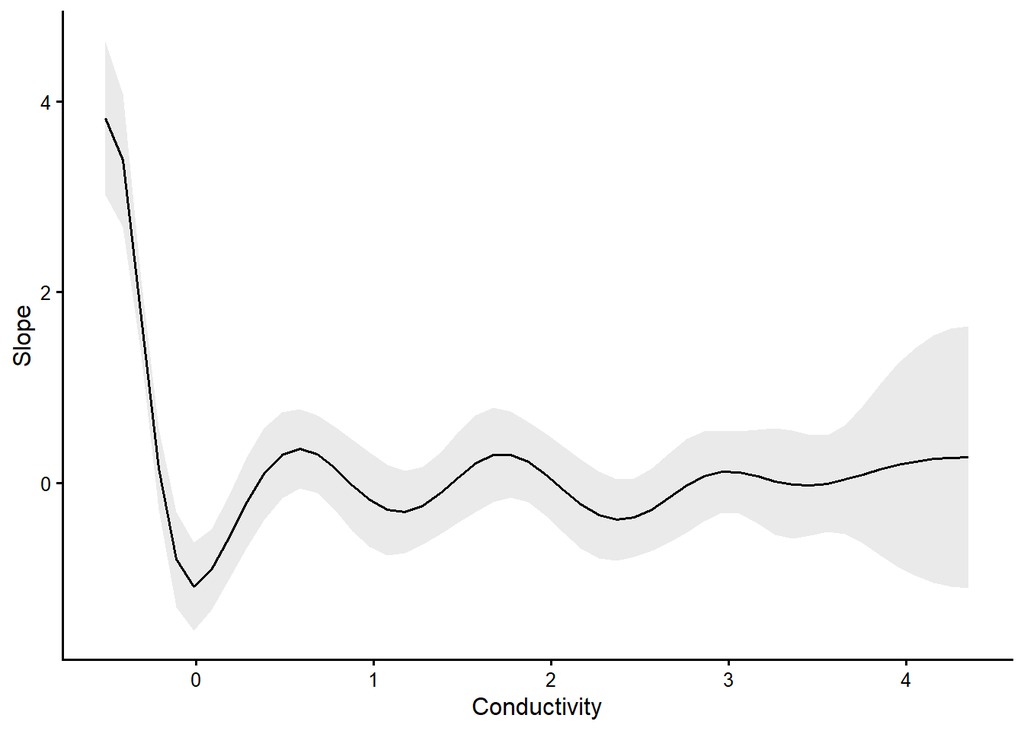

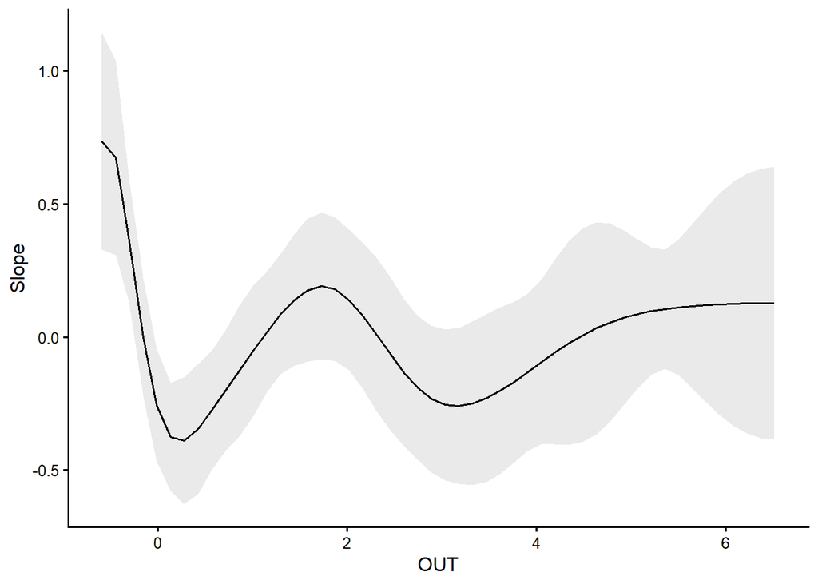

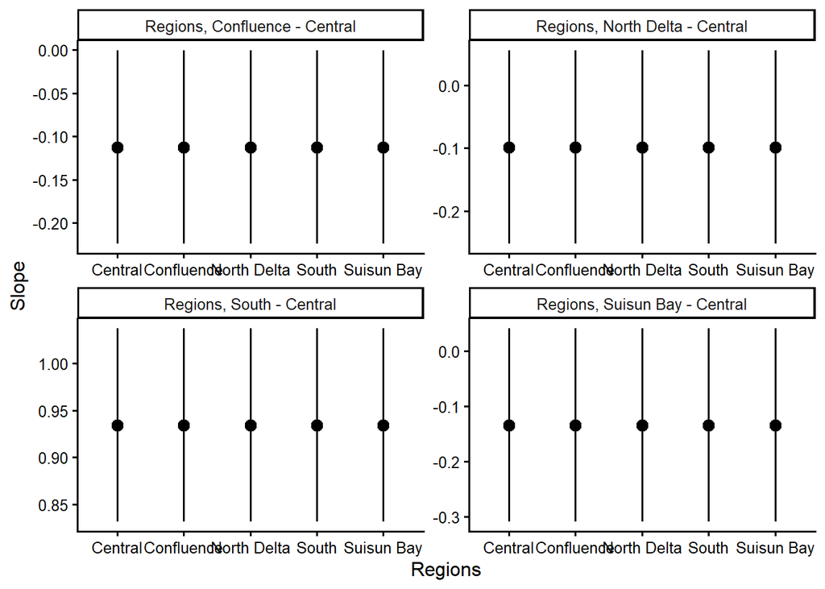

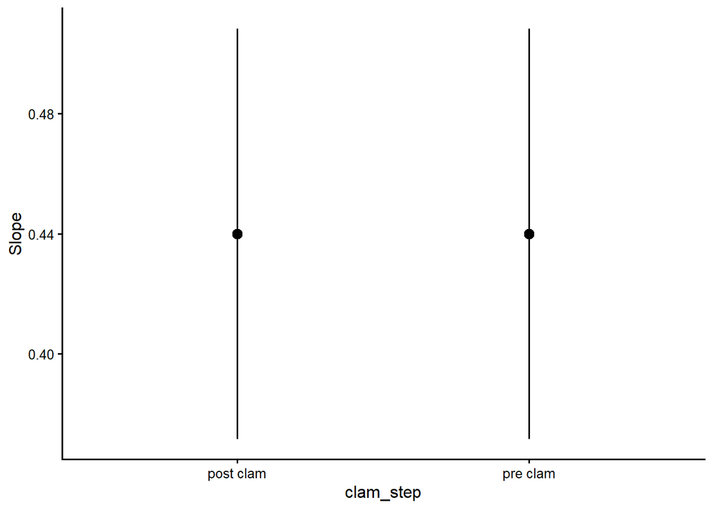

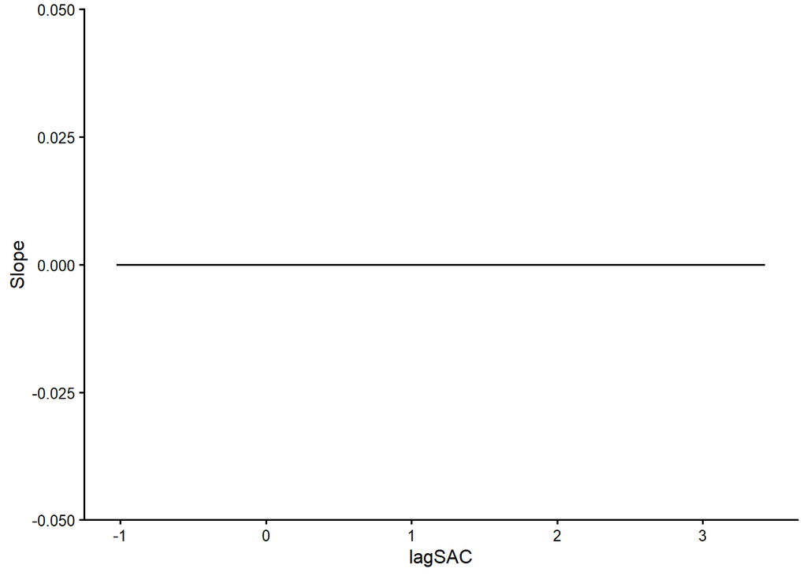

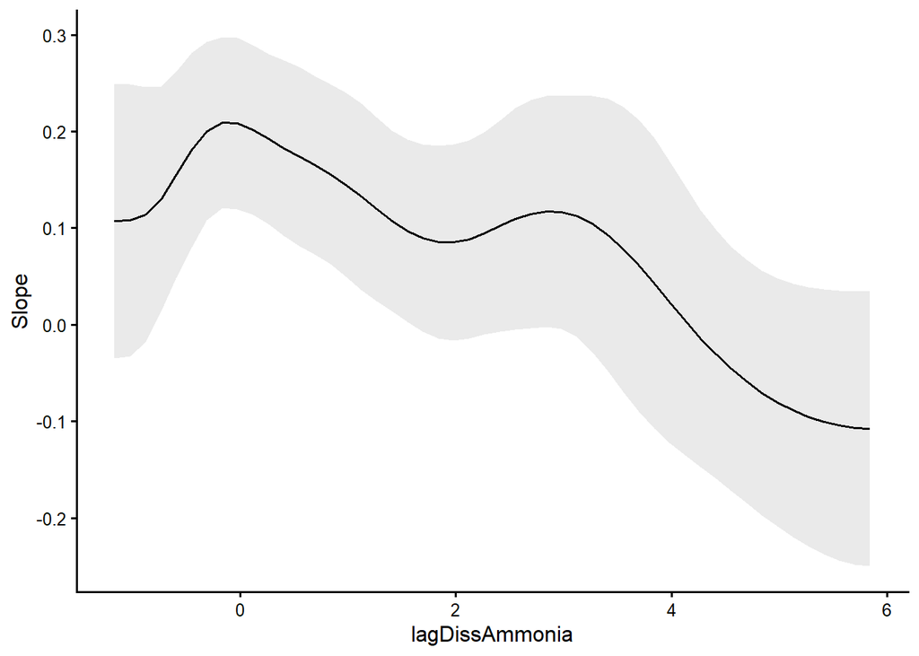

```r
c <- c("DissAmmonia",
          "DissNitrateNitrite",
          "Temperature",
          "Conductivity",
          "OUT",
          "Regions",
          "clam_step",
          "lagSAC",
          "lagDissAmmonia")


lapply(c, function(x) {
  plot_slopes(m3.no.season.shrink, variables = x , condition = x) +
    theme_classic(base_size = 12)
})
```

### diagnostics

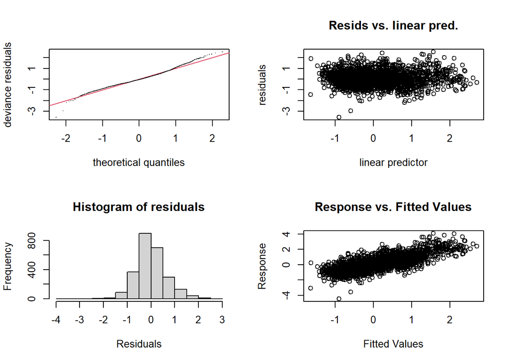

```
##
## Method: ML   Optimizer: outer newton
## full convergence after 18 iterations.
## Gradient range [-0.0003303155,0.0003910405]
## (score 2579.128 & scale 0.4112123).
## Hessian positive definite, eigenvalue range [1.82889e-05,1274.049].
## Model rank =  79 / 79
##
## Basis dimension (k) checking results. Low p-value (k-index<1) may
## indicate that k is too low, especially if edf is close to k'.
##
##                            k'  edf k-index p-value
## s(DissAmmonia)           9.00 4.58      NA      NA
## s(DissNitrateNitrite)    9.00 3.83      NA      NA
## s(Temperature)           9.00 6.78      NA      NA
## s(Conductivity)          9.00 8.42      NA      NA
## s(OUT)                   9.00 6.69      NA      NA
## s(Regions)               5.00 3.93      NA      NA
## s(lagOUT)                9.00 6.67      NA      NA
## s(lagDissAmmonia)        9.00 3.07      NA      NA
## s(lagDissNitrateNitrite) 9.00 5.34      NA      NA
```

```r
gam.check(m3.no.season.shrink)
```

## m4.no.season

m4.no.season: SAC, no season or SAC:season

- gam((logchla) ~ s(DissAmmonia) + s(DissNitrateNitrite) + s(Temperature) + s(Conductivity, k=12) + s(SAC)+s(Regions, bs=‘re’) + clam_step + s(lagSAC) + s(lagDissAmmonia)+ s(lagDissNitrateNitrite)

### concurvity

<0.3 - low, >0.5 - some concern, >0.8 - very high

```r
concurvity(m4.no.season.shrink)
```

```
##          para s(DissAmmonia) s(DissNitrateNitrite) s(Temperature)
## worst       1      0.5366321             0.8003976      0.5643370
## observed    1      0.5116340             0.4596277      0.4364308
## estimate    1      0.2143097             0.3928924      0.4694377
##          s(Conductivity)    s(SAC) s(Regions) s(lagSAC) s(lagDissAmmonia)
## worst          0.8579753 0.5973361  1.0000000 0.5580809         0.5909507
## observed       0.5103499 0.3811443  0.6927023 0.5418494         0.5245311
## estimate       0.5568161 0.4367692  0.7036474 0.4315759         0.3030742
##          s(lagDissNitrateNitrite)
## worst                   0.8154625
## observed                0.7103096
## estimate                0.5135997
```

Print predictor combinations with worst-case index of concurvity >0.5

```r
w<- concurvity(m4.no.season.shrink, full =FALSE)
wdf<- as.data.frame(w$worst)
i <- which(wdf > 0.5, arr.ind = TRUE)
r <- data.frame(
  Row = rownames(wdf)[i[, 1]],
  Column = colnames(wdf)[i[, 2]],
  Value = wdf[i]
)
r <- r[r$Row != r$Column, ]
r
```

|  | Row | Column | Value |
| --- | --- | --- | --- |
| 2 | s(Regions) | para | 1.0000000 |
| 5 | s(Regions) | s(DissNitrateNitrite) | 0.5971421 |
| 6 | s(lagDissNitrateNitrite) | s(DissNitrateNitrite) | 0.5346351 |
| 9 | s(Regions) | s(Conductivity) | 0.7778515 |
| 11 | para | s(Regions) | 1.0000000 |
| 12 | s(DissNitrateNitrite) | s(Regions) | 0.5971421 |
| 13 | s(Conductivity) | s(Regions) | 0.7778515 |
| 15 | s(lagDissNitrateNitrite) | s(Regions) | 0.6575696 |
| 18 | s(DissNitrateNitrite) | s(lagDissNitrateNitrite) | 0.5346351 |
| 19 | s(Regions) | s(lagDissNitrateNitrite) | 0.6575696 |